# User Cars Cost: EDA and Regression

### Target by Features Go to TOC

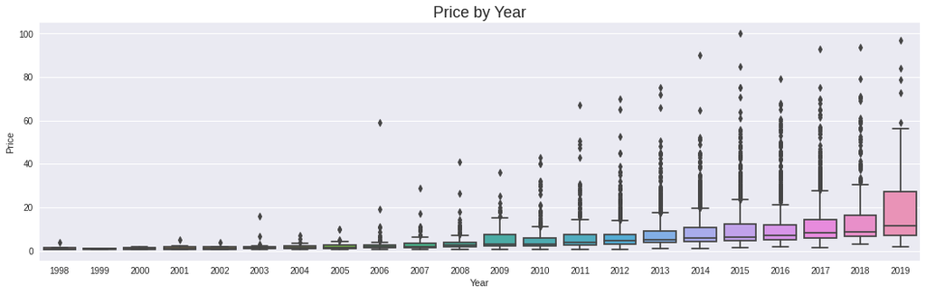

```python
# The bigger the year tends to be the higher the price
describe_y_by_x_cat_boxplot(df_train, 'Year', 'Price', figsize=(18,5))
```

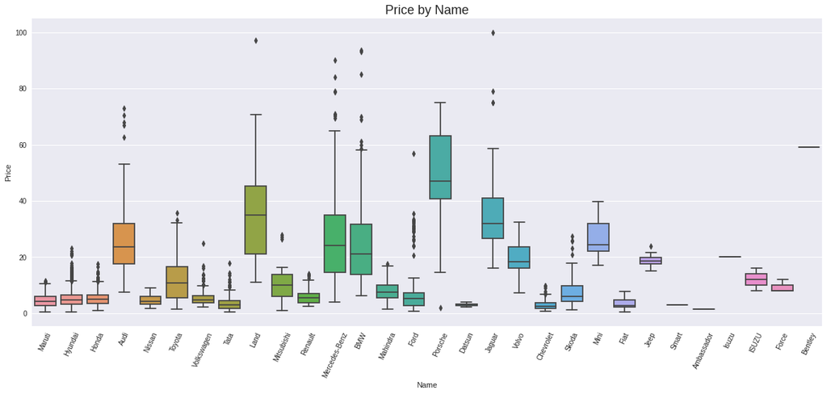

```python
describe_y_by_x_cat_boxplot(df_train, 'Name', 'Price', figsize=(20,8), rotatioon_degree=65)
```

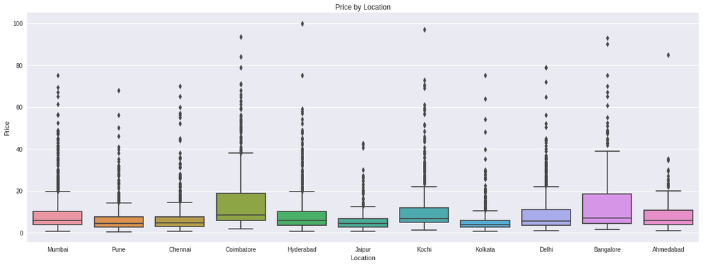

```python
fig, (ax1) = plt.subplots(figsize = (20,7))

sns.boxplot(x="Location", y="Price", data=df_train, ax=ax1)
ax1.set_title('Price by Location')
plt.show()
```

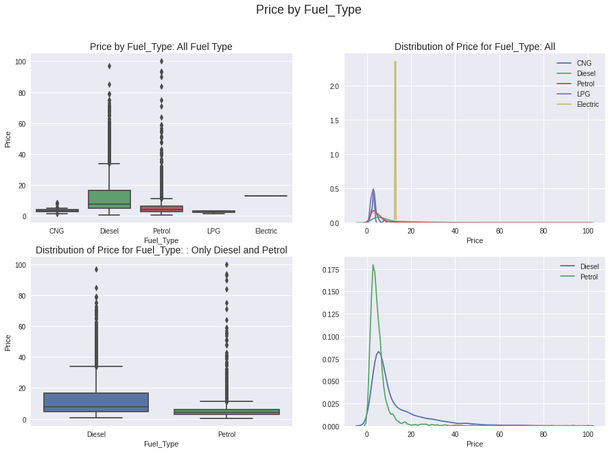

```python
fig, ((ax1, ax2), (ax3, ax4)) = plt.subplots(figsize = (15,10), ncols=2, nrows=2, sharex=False, sharey=False)
font_size = 14
fig.suptitle('Price by Fuel_Type', fontsize=18)

sns.boxplot(x="Fuel_Type", y="Price", data=df_train, ax=ax1)
sns.distplot(df_train[(df_train.Fuel_Type == 'CNG')]["Price"],ax=ax2, hist=False, label='CNG')
sns.distplot(df_train[(df_train.Fuel_Type == 'Diesel')]['Price'],ax=ax2, hist=False, label='Diesel')
sns.distplot(df_train[(df_train.Fuel_Type == 'Petrol')]['Price'],ax=ax2, hist=False, label='Petrol')
sns.distplot(df_train[(df_train.Fuel_Type == 'LPG')]['Price'],ax=ax2, hist=False, label='LPG')
sns.distplot(df_train[(df_train.Fuel_Type == 'Electric')]['Price'],ax=ax2, hist=False, label='Electric')

# Only Diesel and Petrol, cuz LPG, Eletric and CNG has few rows
df_real_fuel = df_train[ (df_train.Fuel_Type == 'Diesel') | (df_train.Fuel_Type == 'Petrol') ]
sns.boxplot(x="Fuel_Type", y="Price", data=df_real_fuel, ax=ax3)
sns.distplot(df_train[(df_train.Fuel_Type == 'Diesel')]['Price'],ax=ax4,hist=False, label='Diesel')
sns.distplot(df_train[(df_train.Fuel_Type == 'Petrol')]['Price'],ax=ax4,hist=False, label='Petrol')

ax1.set_title('Price by Fuel_Type: All Fuel Type', fontsize=font_size)
ax2.set_title('Distribution of Price for Fuel_Type: All', fontsize=font_size)
ax3.set_title('Price by Fuel_Type: Only Diesel and Petrol', fontsize=font_size)
ax3.set_title('Distribution of Price for Fuel_Type: : Only Diesel and Petrol', fontsize=font_size)

plt.show()
```

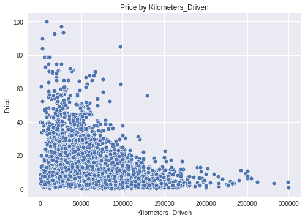

```python
ax = sns.scatterplot(x="Kilometers_Driven", y="Price", data=df_train)
ax.set_title("Price by Kilometers_Driven")
plt.show()
```

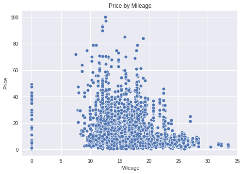

```python
ax = sns.scatterplot(x="Mileage", y="Price", data=df_train)
ax.set_title("Price by Mileage")
plt.show()
```

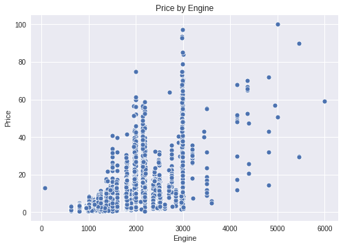

```python
ax = sns.scatterplot(x="Engine", y="Price", data=df_train)
ax.set_title("Price by Engine")
plt.show()
```

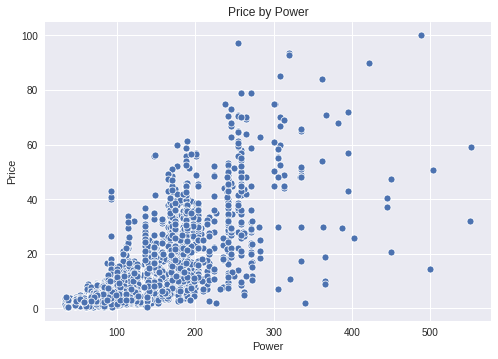

```python
ax = sns.scatterplot(x="Power", y="Price", data=df_train)
ax.set_title("Price by Power")
plt.show()
```

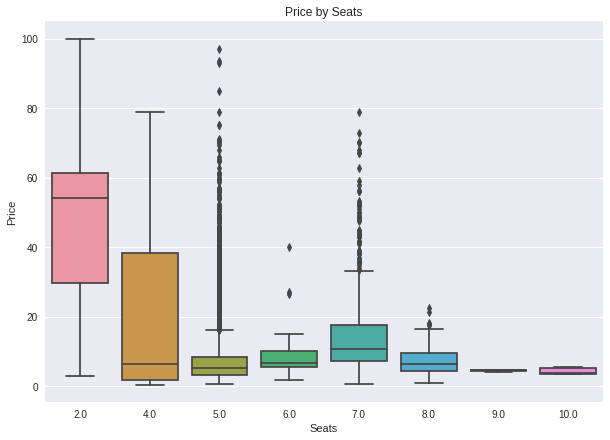

```python
fig, (ax1) = plt.subplots(figsize = (10,7))

sns.boxplot(x="Seats", y="Price", data=df_train, ax=ax1)
ax1.set_title('Price by Seats')
plt.show()
```

### Target by cross Features Go to TOC

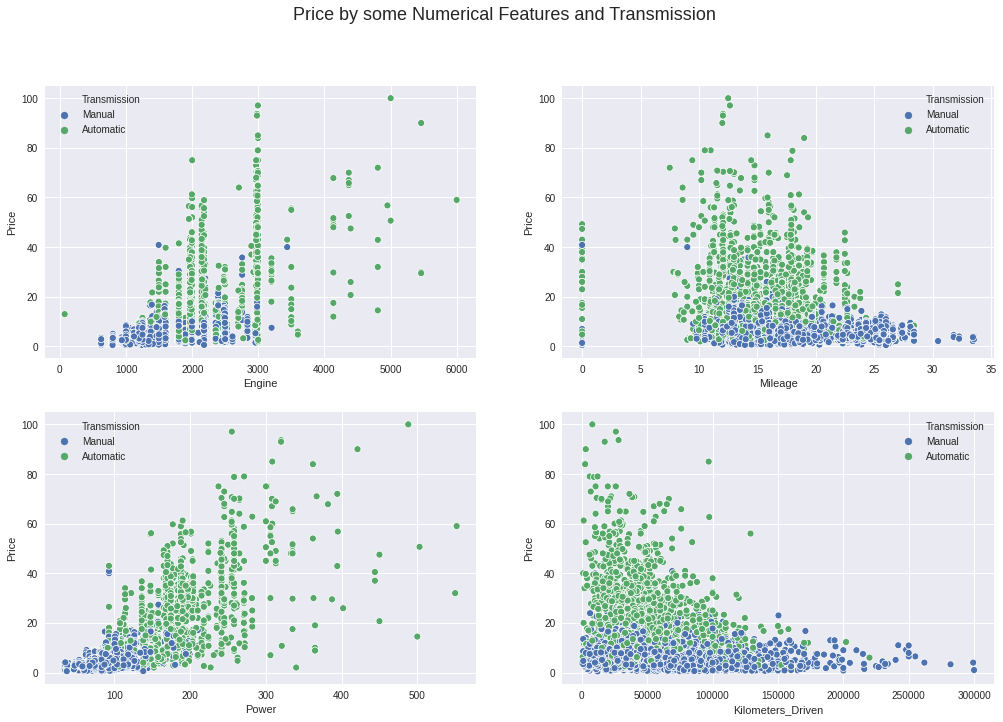

```python
fig, ((ax1, ax2), (ax3, ax4)) = plt.subplots(figsize = (17,11), ncols=2, nrows=2, sharex=False, sharey=False)

sns.scatterplot(x="Engine",  y="Price", hue="Transmission", data=df_train, ax=ax1)
sns.scatterplot(x="Mileage", y="Price", hue="Transmission", data=df_train, ax=ax2)
sns.scatterplot(x="Power",   y="Price", hue="Transmission", data=df_train, ax=ax3)
sns.scatterplot(x="Kilometers_Driven", y="Price", hue="Transmission", data=df_train, ax=ax4)

fig.suptitle('Price by some Numerical Features and Transmission', fontsize=18)
plt.show()
```

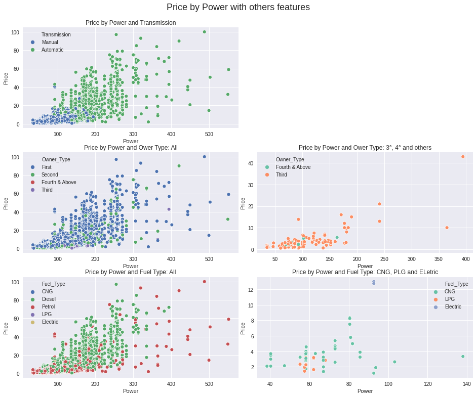

```python
fig, ((ax1, ax2), (ax3, ax4), (ax5, ax6)) = plt.subplots(figsize = (13,11), ncols=2, nrows=3)

sns.scatterplot(x="Power", y="Price", hue="Transmission", data=df_train, ax=ax1)
ax2.remove()

sns.scatterplot(x="Power", y="Price", hue="Owner_Type", data=df_train, ax=ax3)
df_train_re = df_train[ (df_train['Owner_Type'] == 'Fourth & Above') | (df_train['Owner_Type'] == 'Third') ]
sns.scatterplot(x="Power", y="Price", hue="Owner_Type", data=df_train_re, ax=ax4, palette='Set2')

sns.scatterplot(x="Power", y="Price", hue="Fuel_Type", data=df_train, ax=ax5)
df_train_re = df_train[ (df_train['Fuel_Type'] == 'Electric') | (df_train['Fuel_Type'] == 'LPG') | (df_train['Fuel_Type'] == 'CNG')]
sns.scatterplot(x="Power", y="Price", hue="Fuel_Type", data=df_train_re, palette='Set2', ax=ax6)

# Config Titles
fig.suptitle('Price by Power with others features', fontsize=18)
ax1.set_title("Price by Power and Transmission")
ax3.set_title("Price by Power and Ower Type: All")
ax4.set_title("Price by Power and Ower Type: 3°, 4° and others")
ax5.set_title("Price by Power and Fuel Type: All")
ax6.set_title("Price by Power and Fuel Type: CNG, PLG and ELetric")

# padding betwen axis
fig.tight_layout(pad=0.4)

# Correct height of suptitle
plt.subplots_adjust(top=0.92)

plt.show()
```

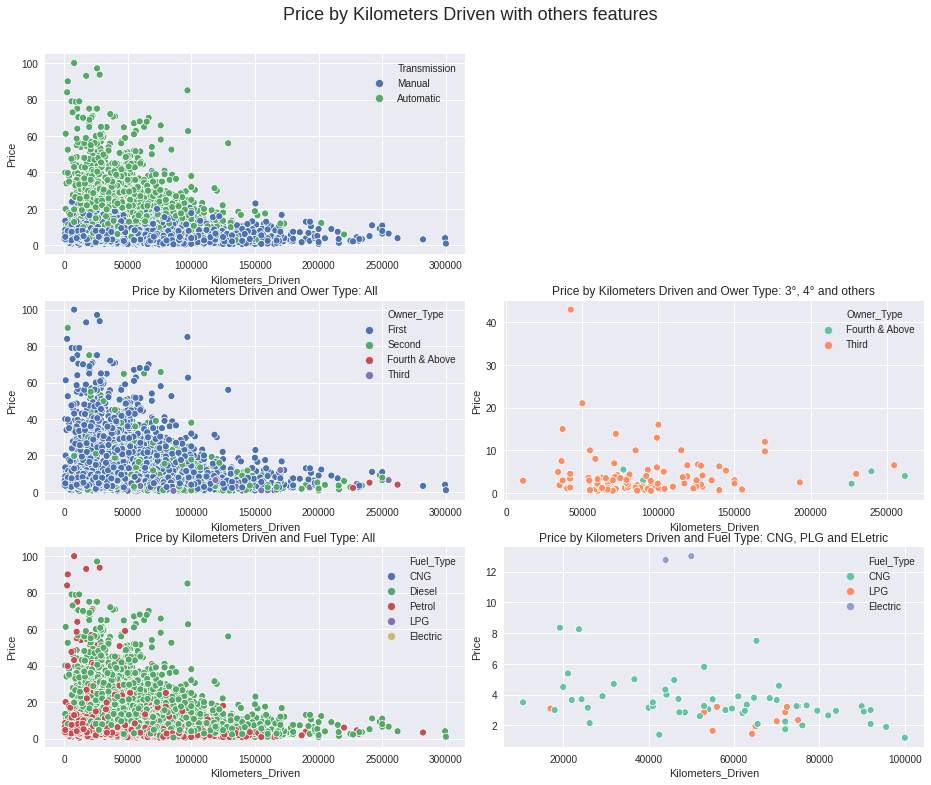

```python
fig, ((ax1, ax2), (ax3, ax4), (ax5, ax6)) = plt.subplots(figsize = (13,11), ncols=2, nrows=3)
ax2.remove()

sns.scatterplot(x="Kilometers_Driven", y="Price", hue="Transmission", data=df_train, ax=ax1)

sns.scatterplot(x="Kilometers_Driven", y="Price", hue="Owner_Type", data=df_train, ax=ax3)
df_train_re = df_train[ (df_train['Owner_Type'] == 'Fourth & Above') | (df_train['Owner_Type'] == 'Third') ]
sns.scatterplot(x="Kilometers_Driven", y="Price", hue="Owner_Type", data=df_train_re, ax=ax4, palette='Set2')

sns.scatterplot(x="Kilometers_Driven", y="Price", hue="Fuel_Type", data=df_train, ax=ax5)
df_train_re = df_train[ (df_train['Fuel_Type'] == 'Electric') | (df_train['Fuel_Type'] == 'LPG') | (df_train['Fuel_Type'] == 'CNG')]
sns.scatterplot(x="Kilometers_Driven", y="Price", hue="Fuel_Type", data=df_train_re, palette='Set2', ax=ax6)

# Config Titles
fig.suptitle('Price by Kilometers Driven with others features', fontsize=18)
ax3.set_title("Price by Kilometers Driven and Ower Type: All")
ax4.set_title("Price by Kilometers Driven and Ower Type: 3°, 4° and others")
ax5.set_title("Price by Kilometers Driven and Fuel Type: All")
ax6.set_title("Price by Kilometers Driven and Fuel Type: CNG, PLG and ELetric")

# padding betwen axis
fig.tight_layout(pad=0.4)

# Correct height of suptitle
plt.subplots_adjust(top=0.92)

plt.show()
```

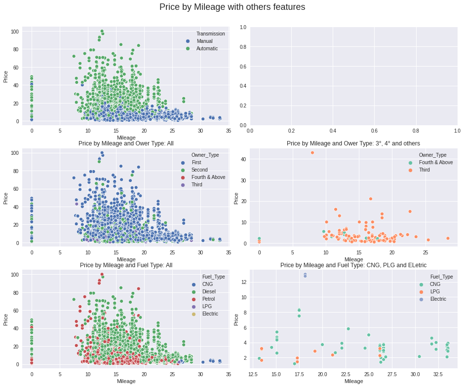

```python
fig, ((ax1, ax2), (ax3, ax4), (ax5, ax6)) = plt.subplots(figsize = (13,11), ncols=2, nrows=3)

sns.scatterplot(x="Mileage", y="Price", hue="Transmission", data=df_train, ax=ax1)

sns.scatterplot(x="Mileage", y="Price", hue="Owner_Type", data=df_train, ax=ax3)
df_train_re = df_train[ (df_train['Owner_Type'] == 'Fourth & Above') | (df_train['Owner_Type'] == 'Third') ]
sns.scatterplot(x="Mileage", y="Price", hue="Owner_Type", data=df_train_re, ax=ax4, palette='Set2')

sns.scatterplot(x="Mileage", y="Price", hue="Fuel_Type", data=df_train, ax=ax5)
df_train_re = df_train[ (df_train['Fuel_Type'] == 'Electric') | (df_train['Fuel_Type'] == 'LPG') | (df_train['Fuel_Type'] == 'CNG')]
sns.scatterplot(x="Mileage", y="Price", hue="Fuel_Type", data=df_train_re, palette='Set2', ax=ax6)

# Config Titles
fig.suptitle('Price by Mileage with others features', fontsize=18)
ax3.set_title("Price by Mileage and Ower Type: All")
ax4.set_title("Price by Mileage and Ower Type: 3°, 4° and others")
ax5.set_title("Price by Mileage and Fuel Type: All")
ax6.set_title("Price by Mileage and Fuel Type: CNG, PLG and ELetric")

# padding betwen axis
fig.tight_layout(pad=0.4)

# Correct height of suptitle
plt.subplots_adjust(top=0.92)

plt.show()
```

### EDA Conclusions Go to TOC

**Target by Feaute**

- Year: The bigger the year the higher the price tends to be
- Name: some names value more than others
- Location: Coimbatore and Bangalore are priced higher than others
- Fuel_Type: Diesel is more expensive than Petrol, and the others have few examples to check better
- Kilometers_Driven: Little Influence
- Milege: Little Influence
- Engine: Linear Infleunce, the higher, the more expensive the price
- Power: Linear Influence, the higher, the more expensive the price
- Seats: Having two seats has a greater influence on the price than the others

**Target by cross Features**

- Transmission: It has an influence on Power, from Power 200 there is only automatic transmission and has the highest prices. It occurs in a similar way to Engine. Analyzing 4 numerical features (Engine, Power, Mileage, Kilometres_Drive) we see that being automatic transmission means having a great price

...

## Pre-Processing Go to TOC

Prepare Train DataSet

```python
df_train.head()
```

|  | Name | Location | Year | Kilometers_Driven | Fuel_Type | Transmission | Owner_Type | Mileage | Engine | Power | Seats | Price |
| --- | --- | --- | --- | --- | --- | --- | --- | --- | --- | --- | --- | --- |
| 0 | Maruti | Mumbai | 2010 | 72000 | CNG | Manual | First | 26.600 | 998.000 | 58.160 | 5.000 | 1.750 |
| 1 | Hyundai | Pune | 2015 | 41000 | Diesel | Manual | First | 19.670 | 1,582.000 | 126.200 | 5.000 | 12.500 |
| 2 | Honda | Chennai | 2011 | 46000 | Petrol | Manual | First | 18.200 | 1,199.000 | 88.700 | 5.000 | 4.500 |
| 3 | Maruti | Chennai | 2012 | 87000 | Diesel | Manual | First | 20.770 | 1,248.000 | 88.760 | 7.000 | 6.000 |
| 4 | Audi | Coimbatore | 2013 | 40670 | Diesel | Automatic | Second | 15.200 | 1,968.000 | 140.800 | 5.000 | 17.740 |

```python
# Name
df_final_train = df_train.drop(['Name'],axis=1)

# Location
df_location = pd.get_dummies(df_train['Location'],drop_first=True)

# Fuel Type
df_fuel_typ = pd.get_dummies(df_train['Fuel_Type'],drop_first=True)

# Transmission
df_final_train['Transmission'].replace( {'Manual': 0, 'Automatic': 1}, inplace=True)

# Owener_Type
df_final_train['Owner_Type'].replace( {'First': 1, 'Second': 2, "Third": 3,"Fourth & Above":4}, inplace=True)

df_final_train = pd.concat([df_final_train, df_location, df_fuel_typ],axis=1).drop(['Location', 'Fuel_Type'],axis=1)
df_final_train.head()
```

|  | Year | Kilometers_Driven | Transmission | Owner_Type | Mileage | Engine | Power | Seats | Price | Bangalore | ... | Hyderabad | Jaipur | Kochi | Kolkata | Mumbai | Pune | Diesel | Electric | LPG | Petrol |
| --- | --- | --- | --- | --- | --- | --- | --- | --- | --- | --- | --- | --- | --- | --- | --- | --- | --- | --- | --- | --- | --- |
| 0 | 2010 | 72000 | 0 | 1 | 26.600 | 998.000 | 58.160 | 5.000 | 1.750 | 0 | ... | 0 | 0 | 0 | 0 | 1 | 0 | 0 | 0 | 0 | 0 |
| 1 | 2015 | 41000 | 0 | 1 | 19.670 | 1,582.000 | 126.200 | 5.000 | 12.500 | 0 | ... | 0 | 0 | 0 | 0 | 0 | 1 | 1 | 0 | 0 | 0 |
| 2 | 2011 | 46000 | 0 | 1 | 18.200 | 1,199.000 | 88.700 | 5.000 | 4.500 | 0 | ... | 0 | 0 | 0 | 0 | 0 | 0 | 0 | 0 | 0 | 1 |
| 3 | 2012 | 87000 | 0 | 1 | 20.770 | 1,248.000 | 88.760 | 7.000 | 6.000 | 0 | ... | 0 | 0 | 0 | 0 | 0 | 0 | 1 | 0 | 0 | 0 |
| 4 | 2013 | 40670 | 1 | 2 | 15.200 | 1,968.000 | 140.800 | 5.000 | 17.740 | 0 | ... | 0 | 0 | 0 | 0 | 0 | 0 | 1 | 0 | 0 | 0 |

5 rows × 23 columns

Prepare Test DataSet

```python
for i in range(df_test.shape[0]):
    try:
        df_test.at[i, 'Name']        = df_test['Name'][i].split()[0] # Get First Name
        df_test.at[i, 'Mileage'] = df_test['Mileage'][i].split()[0] # Get Number
        df_test.at[i, 'Engine']     = df_test['Engine'][i].split()[0] # Get Number
        df_test.at[i, 'Power']     = df_test['Power'][i].split()[0] # Get Number
    except:
        pass # is nan or string

# # Engine :: 998 CC

replace_engine = {'1798 CC': '1798', '72 CC': '72'}
df_test['Engine'] = df_test['Engine'].replace(replace_engine).astype(float)
median_engine = df_test['Engine'].median()
df_test['Engine'] = df_test['Engine'].fillna(median_engine)

# # Mileage :: 26.6 km/kg || 19.67 kmpl
df_test['Mileage'] = df_test['Mileage'].astype(float)
df_test['Mileage'] = df_test['Mileage'].fillna( df_test['Mileage'].median() )

# # Power :: 58.16 bhp
replace_power = {'nan': '-1', 'null': '-1', '73 bhp': '-1', '41 bhp': '-1'}
df_test['Power'] = df_test['Power'].replace(replace_power)
median_power = df_test['Power'].median()
df_test['Power'] = df_test['Power'].replace({-1: median_power}).fillna(median_power).astype(float)
df_test['Power'] = df_test['Power'].replace({-1: median_power})

# # Seats :: float WARNING: There Are Seat=0 (Error)
median_seats = df_test['Seats'].median()
df_test['Seats'] = df_test['Seats'].replace({0.0: median_seats}).fillna(median_seats).astype(float)

df_test.isnull().sum()
```

```
Unnamed: 0              0
Name                    0
Location                0
Year                    0
Kilometers_Driven       0
Fuel_Type               0
Transmission            0
Owner_Type              0
Mileage                 0
Engine                  0
Power                   0
Seats                   0
New_Price            1052
dtype: int64
```

```python
# Name
df_final_test = df_test.drop(['Name','New_Price','Unnamed: 0'],axis=1)

# Location
df_location = pd.get_dummies(df_test['Location'],drop_first=True)

# Fuel Type
df_fuel_typ = pd.get_dummies(df_test['Fuel_Type'],drop_first=True)

# Transmission
df_final_test['Transmission'].replace( {'Manual': 0, 'Automatic': 1}, inplace=True)

# Owener_Type
df_final_test['Owner_Type'].replace( {'First': 1, 'Second': 2, "Third": 3,"Fourth & Above":4}, inplace=True)

df_final_test = pd.concat([df_final_test, df_location, df_fuel_typ],axis=1).drop(['Location', 'Fuel_Type'],axis=1)
df_final_test.head()
```

|  | Year | Kilometers_Driven | Transmission | Owner_Type | Mileage | Engine | Power | Seats | Bangalore | Chennai | ... | Delhi | Hyderabad | Jaipur | Kochi | Kolkata | Mumbai | Pune | Diesel | LPG | Petrol |
| --- | --- | --- | --- | --- | --- | --- | --- | --- | --- | --- | --- | --- | --- | --- | --- | --- | --- | --- | --- | --- | --- |
| 0 | 2014 | 40929 | 0 | 1 | 32.260 | 998.000 | 58.200 | 4.000 | 0 | 0 | ... | 1 | 0 | 0 | 0 | 0 | 0 | 0 | 0 | 0 | 0 |
| 1 | 2013 | 54493 | 0 | 2 | 24.700 | 796.000 | 47.300 | 5.000 | 0 | 0 | ... | 0 | 0 | 0 | 0 | 0 | 0 | 0 | 0 | 0 | 1 |
| 2 | 2017 | 34000 | 0 | 1 | 13.680 | 2,393.000 | 147.800 | 7.000 | 0 | 0 | ... | 0 | 0 | 0 | 0 | 0 | 1 | 0 | 1 | 0 | 0 |
| 3 | 2012 | 139000 | 0 | 1 | 23.590 | 1,364.000 | 91.100 | 5.000 | 0 | 0 | ... | 0 | 1 | 0 | 0 | 0 | 0 | 0 | 1 | 0 | 0 |
| 4 | 2014 | 29000 | 0 | 1 | 18.500 | 1,197.000 | 82.850 | 5.000 | 0 | 0 | ... | 0 | 0 | 0 | 0 | 0 | 1 | 0 | 0 | 0 | 1 |

5 rows × 21 columns

## Correlations Go to TOC

```python
df_final_train.head()
```

|  | Year | Kilometers_Driven | Transmission | Owner_Type | Mileage | Engine | Power | Seats | Price | Bangalore | ... | Hyderabad | Jaipur | Kochi | Kolkata | Mumbai | Pune | Diesel | Electric | LPG | Petrol |
| --- | --- | --- | --- | --- | --- | --- | --- | --- | --- | --- | --- | --- | --- | --- | --- | --- | --- | --- | --- | --- | --- |
| 0 | 2010 | 72000 | 0 | 1 | 26.600 | 998.000 | 58.160 | 5.000 | 1.750 | 0 | ... | 0 | 0 | 0 | 0 | 1 | 0 | 0 | 0 | 0 | 0 |
| 1 | 2015 | 41000 | 0 | 1 | 19.670 | 1,582.000 | 126.200 | 5.000 | 12.500 | 0 | ... | 0 | 0 | 0 | 0 | 0 | 1 | 1 | 0 | 0 | 0 |
| 2 | 2011 | 46000 | 0 | 1 | 18.200 | 1,199.000 | 88.700 | 5.000 | 4.500 | 0 | ... | 0 | 0 | 0 | 0 | 0 | 0 | 0 | 0 | 0 | 1 |
| 3 | 2012 | 87000 | 0 | 1 | 20.770 | 1,248.000 | 88.760 | 7.000 | 6.000 | 0 | ... | 0 | 0 | 0 | 0 | 0 | 0 | 1 | 0 | 0 | 0 |
| 4 | 2013 | 40670 | 1 | 2 | 15.200 | 1,968.000 | 140.800 | 5.000 | 17.740 | 0 | ... | 0 | 0 | 0 | 0 | 0 | 0 | 1 | 0 | 0 | 0 |

5 rows × 23 columns

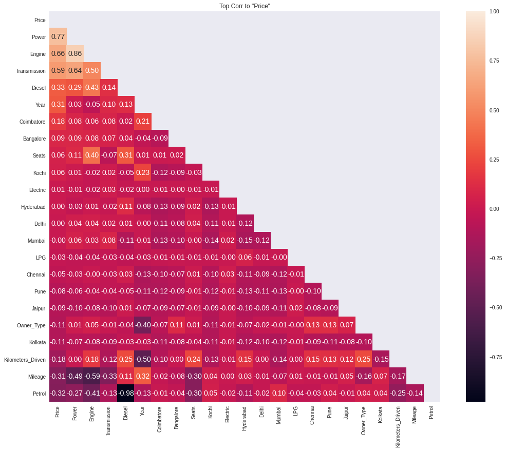

```python
corr_matrix = df_final_train.corr()
f, ax1 = plt.subplots(figsize=(18, 14), sharex=False)

ax1.set_title('Top Corr to {}'.format('"Price"'))
cols_top = corr_matrix.sort_values(by="Price", ascending=False)['Price'].index

cm = np.corrcoef(df_final_train[cols_top].values.T)
mask = np.zeros_like(cm)
mask[np.triu_indices_from(mask)] = True
hm = sns.heatmap(cm, cbar=True, annot=True, square=True, fmt='.2f',
                 annot_kws={'size': 14}, yticklabels=cols_top.values,
                 xticklabels=cols_top.values, mask=mask, ax=ax1)

# see the leftmost column, it's the correlations ordered from highest to lowest for Price
```

## Split in train and Test Go to TOC

```python
from sklearn.model_selection import train_test_split


X = df_final_train.loc[:, df_final_train.columns != 'Price'].values
Y = df_final_train['Price'].values

x_features = df_final_train.loc[:, df_final_train.columns != 'Price'].columns.tolist()

x_train, x_test, y_train, y_test = train_test_split(X, Y, test_size = 0.2, random_state = 42)
```

## Develop Models Go to TOC

### Prepare ML Models and Training Go to TOC

```python
from sklearn.model_selection import GridSearchCV, KFold, cross_val_score, train_test_split
from sklearn.neural_network import MLPRegressor
from sklearn.preprocessing import OneHotEncoder, LabelEncoder, StandardScaler, RobustScaler, scale
from sklearn.decomposition import PCA
from sklearn.linear_model import ElasticNet, LassoCV, BayesianRidge, LassoLarsIC
from sklearn.linear_model import Ridge, RidgeCV, ElasticNet, ElasticNetCV, LinearRegression
from sklearn.kernel_ridge import KernelRidge
from mlxtend.regressor import StackingCVRegressor
from sklearn.pipeline import make_pipeline
from sklearn.ensemble import RandomForestRegressor, GradientBoostingRegressor, ExtraTreesRegressor
from sklearn.ensemble import AdaBoostRegressor, BaggingRegressor
from sklearn.metrics import mean_squared_error, r2_score
from sklearn.base import BaseEstimator, TransformerMixin, RegressorMixin, clone
from sklearn.svm import SVR

from lightgbm import LGBMRegressor
from xgboost import XGBRegressor
```

```python
# Setup cross validation folds
kf = KFold(n_splits=4, random_state=42, shuffle=True)

# Define error metrics
def rmse(y, y_pred):
    return np.sqrt(mean_squared_error(y, y_pred))

def cv_rmse(model, X=x_train):
    rmse = np.sqrt(-cross_val_score(model, X, y_train, scoring="neg_mean_squared_error", cv=kf))
    return (rmse)
```

```python
# Create ML Models

# Light Gradient Boosting Regressor
lightgb_model = LGBMRegressor(objective='regression',  num_leaves=6, learning_rate=0.01,  n_estimators=7000,
                       max_bin=200,  bagging_fraction=0.8, bagging_freq=4,  bagging_seed=8,
                       feature_fraction=0.2, feature_fraction_seed=8, min_sum_hessian_in_leaf = 11,
                       verbose=-1, random_state=42)

# XGBoost Regressor
xgboost_model = XGBRegressor(learning_rate=0.01, n_estimators=6000, max_depth=4, min_child_weight=0,
                       gamma=0.6, subsample=0.7, colsample_bytree=0.7, objective='reg:squarederror',
                       nthread=-1, scale_pos_weight=1, seed=42, reg_alpha=0.00006, random_state=42)

# Linear Regressor
linear_model = LinearRegression()

# Ridge Regressor
ridge_alphas = [1e-15, 1e-10, 1e-8, 9e-4, 7e-4, 5e-4, 3e-4, 1e-4,
                1e-3, 5e-2, 1e-2, 0.1, 0.3, 1, 3, 5, 10, 15, 18, 20, 30, 50, 75, 100]
ridge_model = make_pipeline(RobustScaler(), RidgeCV(alphas=ridge_alphas, cv=kf))

# Lasso Regressor
lasso_alphas2 = [5e-05, 0.0001, 0.0008, 0.01, 0.1, 1]
lasso_model = make_pipeline(RobustScaler(),
                      LassoCV(max_iter=1e7, alphas=lasso_alphas2,
                              random_state=42, cv=kf))

# Elastic Net Regressor
elastic_alphas = [0.0001, 0.0002, 0.0003, 0.0004, 0.0005, 0.0006, 0.0007]
elastic_l1ratio = [0.8, 0.85, 0.9, 0.95, 0.99, 1]
elasticnet_model = make_pipeline(RobustScaler(),
                           ElasticNetCV(max_iter=1e7, alphas=elastic_alphas,
                                        cv=kf, l1_ratio=elastic_l1ratio))

# Kernel Ridge
keridge_model = KernelRidge(alpha=0.6, kernel='polynomial', degree=2, coef0=2.5)

# Support Vector Regressor
svm_model = make_pipeline(RobustScaler(), SVR(C= 20, epsilon= 0.008, gamma=0.0003))

# Gradient Boosting Regressor
gboost_model = GradientBoostingRegressor(n_estimators=6000, learning_rate=0.01, max_depth=4, max_features='sqrt',
                                min_samples_leaf=15, min_samples_split=10, loss='huber', random_state=42)

# Random Forest Regressor
randomforest_model = RandomForestRegressor(n_estimators=1200, max_depth=15, min_samples_split=5, min_samples_leaf=5,
                          max_features=None, oob_score=True, random_state=42)

# Neural Net
neuralnet_model = MLPRegressor()

# Extra Tree Regressor
extratree_model = ExtraTreesRegressor()
```

```python
regressor_models = {
    'Linear': linear_model,
    'Ridge': ridge_model,
    'Lasso': lasso_model,
    'KernelRidge': keridge_model,
    'ElasticNet': elasticnet_model,
    'SVM': svm_model,
    'RandomForest': randomforest_model,
    'ExtraTree': extratree_model,
    'NeuralNet': neuralnet_model,
    'GBoost': gboost_model,
    'LightGB': lightgb_model,
    'XGBoost': xgboost_model,
}
```

### Cross Validation Go to TOC

```python
## Cross Validation

cv_scores = {}
t_start = time.time()

for model_name, model in regressor_models.items():
    print('{:17}'.format(model_name), end='')
    t0 = time.time()
    score = cv_rmse(model)
    m, s = score.mean(), score.std()
    cv_scores[model_name] = [m,s]
    print('| MSE in CV | rmse_mean: {:11,.3f}, | rmse_std: {:9,.3f}  | took: {:9,.3f} s |'.format(m,s, time.time() - t0))

print('\nTime total to CrossValidation: took {:9,.3f} s'.format(time.time() - t_start)) # 200s

# Show Sorted Train Scores DataFrame
df_cv = pd.DataFrame(data = cv_scores.values(), columns=['rmse_cv', 'std_cv'], index=cv_scores.keys())
df_cv = df_cv.sort_values(by='rmse_cv').reset_index().rename({'index': 'model'}, axis=1)
df_cv
```

```
Linear           | MSE in CV | rmse_mean:       5.860, | rmse_std:     0.663  | took:     0.053 s |
Ridge            | MSE in CV | rmse_mean:       5.855, | rmse_std:     0.672  | took:     0.828 s |
Lasso            | MSE in CV | rmse_mean:       5.858, | rmse_std:     0.666  | took:     0.134 s |
KernelRidge      | MSE in CV | rmse_mean:       5.048, | rmse_std:     0.530  | took:    49.030 s |
ElasticNet       | MSE in CV | rmse_mean:       5.860, | rmse_std:     0.664  | took:     0.425 s |
SVM              | MSE in CV | rmse_mean:       7.119, | rmse_std:     0.827  | took:     5.315 s |
RandomForest     | MSE in CV | rmse_mean:       3.801, | rmse_std:     0.549  | took:    52.853 s |
ExtraTree        | MSE in CV | rmse_mean:       3.754, | rmse_std:     0.624  | took:     4.711 s |
NeuralNet        | MSE in CV | rmse_mean:       8.602, | rmse_std:     1.983  | took:     4.176 s |
GBoost           | MSE in CV | rmse_mean:       3.336, | rmse_std:     0.523  | took:   101.030 s |
LightGB          | MSE in CV | rmse_mean:       3.490, | rmse_std:     0.475  | took:     8.231 s |
XGBoost          | MSE in CV | rmse_mean:       3.177, | rmse_std:     0.508  | took:    72.407 s |

Time total to CrossValidation: took   299.198 s
```

|  | model | rmse_cv | std_cv |
| --- | --- | --- | --- |
| 0 | XGBoost | 3.177 | 0.508 |
| 1 | GBoost | 3.336 | 0.523 |
| 2 | LightGB | 3.490 | 0.475 |
| 3 | ExtraTree | 3.754 | 0.624 |
| 4 | RandomForest | 3.801 | 0.549 |
| 5 | KernelRidge | 5.048 | 0.530 |
| 6 | Ridge | 5.855 | 0.672 |
| 7 | Lasso | 5.858 | 0.666 |
| 8 | ElasticNet | 5.860 | 0.664 |
| 9 | Linear | 5.860 | 0.663 |
| 10 | SVM | 7.119 | 0.827 |
| 11 | NeuralNet | 8.602 | 1.983 |

## Fit Models Go to TOC

```python
# Def Stack Model: Stack up some the models above, optimized using one ml model
stack_regressors = (regressor_models['XGBoost'],
                    regressor_models['GBoost'],
                    regressor_models['LightGB'],
                    regressor_models['RandomForest'],
                    regressor_models['ExtraTree']
                   )

stack_model = StackingCVRegressor(regressors = stack_regressors,
                                meta_regressor = regressor_models['XGBoost'],
                                use_features_in_secondary=True)

regressor_models['Stack'] = stack_model
```

```python
train_scores = {}
t_start = time.time()

for model_name, model in regressor_models.items():
    print('{:14}'.format(model_name), end='')
    t0 = time.time()
    if(model_name == 'Stack'):
        model  = model.fit(np.array(x_train), np.array(y_train))
        y_pred = model.predict(np.array(x_train))
    else:
        model  = model.fit( x_train, y_train )
        y_pred = model.predict(x_train)
    r2, mse = r2_score(y_train, y_pred), mean_squared_error(y_train, y_pred)
    train_scores[model_name] = [r2, mse, np.sqrt(mse)]
    text_print = '| Train | r2: {:5,.3f} | mse: {:7,.3f}  | took: {:9,.3f} s |'
    print(text_print.format(r2, mse, time.time() - t0))
    regressor_models[model_name] = model

print('\nTime total to Fit Models: took {:9,.3f} s'.format(time.time() - t_start)) # UsedCars: 686 s = 11min
```

```
Linear        | Train | r2: 0.723 | mse:  34.265  | took:     0.006 s |
Ridge         | Train | r2: 0.722 | mse:  34.277  | took:     0.211 s |
Lasso         | Train | r2: 0.723 | mse:  34.268  | took:     0.043 s |
KernelRidge   | Train | r2: 0.811 | mse:  23.305  | took:    55.336 s |
ElasticNet    | Train | r2: 0.723 | mse:  34.267  | took:     0.127 s |
SVM           | Train | r2: 0.602 | mse:  49.193  | took:     3.053 s |
RandomForest  | Train | r2: 0.941 | mse:   7.287  | took:    17.898 s |
ExtraTree     | Train | r2: 1.000 | mse:   0.000  | took:     1.643 s |
NeuralNet     | Train | r2: 0.674 | mse:  40.289  | took:     1.249 s |
GBoost        | Train | r2: 0.953 | mse:   5.850  | took:    30.544 s |
LightGB       | Train | r2: 0.945 | mse:   6.785  | took:     4.549 s |
XGBoost       | Train | r2: 0.992 | mse:   0.993  | took:    24.586 s |
Stack         | Train | r2: 0.960 | mse:   4.924  | took:   425.715 s |

Time total to Fit Models: took   564.966 s
```

```python
# Blend Model is use a porcentage of some models mixing
class BlendModel:

    @classmethod
    def predict(self, X):
        return ((0.10 * regressor_models['LightGB'].predict(X)) + \
            (0.10 * regressor_models['GBoost'].predict(X)) + \
            (0.15 * regressor_models['XGBoost'].predict(X)) + \
            (0.10 * regressor_models['LightGB'].predict(X)) + \
            (0.20 * regressor_models['RandomForest'].predict(X)) + \
            (0.35 * regressor_models['Stack'].predict(np.array(X))))

regressor_models['BlendModel'] = BlendModel()
y_pred = BlendModel.predict(x_train)
r2, mse = r2_score(y_train, y_pred), mean_squared_error(y_train, y_pred)
train_scores['BlendModel'] = [r2, mse, np.sqrt(mse)]
print('RMSE score on train data to Blend Model:\n\t=>', np.sqrt(mse))
```

```
RMSE score on train data to Blend Model:
	=> 1.8362338597312082
```

```python
from mlens.ensemble import SuperLearner

# create a list of base-models
def get_models_to_super_leaner():
    models = list()
    models.append(regressor_models['LightGB'])
    models.append(regressor_models['GBoost'])
    models.append(regressor_models['XGBoost'])
    models.append(regressor_models['LightGB'])
    models.append(regressor_models['ExtraTree'])
    models.append(regressor_models['RandomForest'])
    models.append(regressor_models['KernelRidge'])
    return models

# create the super learner
def get_super_learner(X):
    ensemble = SuperLearner(scorer=rmse, folds=5, shuffle=True, sample_size=len(X))
    # add base models
    models = get_models_to_super_leaner()
    ensemble.add(models)
    # add the meta model
    ensemble.add_meta(LinearRegression())
    return ensemble

# key to regressros models
model_name = 'SuperLeaner'

# create the super learner
ensemble = get_super_learner(x_train)
# fit the super learner
t0 = time.time()
ensemble.fit(x_train, np.array(y_train)) # UsedCars: took 565s = 10min
# pred and evaluate in train dataset
y_pred = ensemble.predict(x_train)
r2, mse = r2_score(y_train, y_pred), mean_squared_error(y_train, y_pred)
train_scores[model_name] = [r2, mse, np.sqrt(mse)]
# show results
text_print = '| Super Leaner in Train | r2: {:6,.3f}, | mse: {:9,.3f}  | took: {:9,.3f} s |\n'
print(text_print.format(r2, mse, time.time() - t0))
# set in dict regressors
regressor_models[model_name] = ensemble
# summarize base learners
print(ensemble.data)
# evaluate meta model
```

```
[MLENS] backend: threading
```

```
| Super Leaner in Train | r2:  0.989, | mse:     1.310  | took:   418.181 s |

                                      score-m  score-s    ft-m   ft-s  pt-m  pt-s
layer-1  extratreesregressor             3.66     0.56    2.29   0.18  0.09  0.02
layer-1  gradientboostingregressor       3.39     0.51  155.67  50.96  0.12  0.00
layer-1  kernelridge                     5.00     0.41   14.38   0.22  0.02  0.01
layer-1  lgbmregressor-1                 3.45     0.42   12.32   2.00  0.36  0.04
layer-1  lgbmregressor-2                 3.45     0.42   12.15   0.72  0.30  0.06
layer-1  randomforestregressor           3.74     0.63   27.83   1.49  0.57  0.09
layer-1  xgbregressor                    3.05     0.57   25.38   4.46  0.34  0.04
```

```python
# Show train_scores dataframe
df_train_scores = pd.DataFrame(data = train_scores.values(),index=train_scores.keys(), columns=['r2_train', 'mse_train', 'rmse_train'])
df_train_scores = df_train_scores.sort_values(by='r2_train', ascending=False).reset_index().rename({'index': 'model'}, axis=1)
df_train_scores
```

|  | model | r2_train | mse_train | rmse_train |
| --- | --- | --- | --- | --- |
| 0 | ExtraTree | 1.000 | 0.000 | 0.022 |
| 1 | XGBoost | 0.992 | 0.993 | 0.997 |
| 2 | SuperLeaner | 0.989 | 1.310 | 1.144 |
| 3 | BlendModel | 0.973 | 3.372 | 1.836 |
| 4 | Stack | 0.960 | 4.924 | 2.219 |
| 5 | GBoost | 0.953 | 5.850 | 2.419 |
| 6 | LightGB | 0.945 | 6.785 | 2.605 |
| 7 | RandomForest | 0.941 | 7.287 | 2.699 |
| 8 | KernelRidge | 0.811 | 23.305 | 4.828 |
| 9 | Linear | 0.723 | 34.265 | 5.854 |
| 10 | ElasticNet | 0.723 | 34.267 | 5.854 |
| 11 | Lasso | 0.723 | 34.268 | 5.854 |
| 12 | Ridge | 0.722 | 34.277 | 5.855 |
| 13 | NeuralNet | 0.674 | 40.289 | 6.347 |
| 14 | SVM | 0.602 | 49.193 | 7.014 |

## Test Models Go to TOC

```python
test_scores = {}

# predcit x_test to y_test and compare
for model_name, model in regressor_models.items():
    if(model_name == 'Stack'):
        y_pred = model.predict(np.array(x_test))
    else:
        y_pred = model.predict(x_test)
    r2, mse = r2_score(y_test, y_pred), mean_squared_error(y_test, y_pred)
    test_scores[model_name] = [r2, mse, np.sqrt(mse)]

# Sort DF test scores
df_test_scores = pd.DataFrame(data = test_scores.values(), columns=['r2_test', 'mse_test', 'rmse_test'], index=test_scores.keys())
df_test_scores = df_test_scores.sort_values(by='r2_test', ascending=False).reset_index().rename({'index': 'model'}, axis=1)
df_test_scores
```

|  | model | r2_test | mse_test | rmse_test |
| --- | --- | --- | --- | --- |
| 0 | XGBoost | 0.928 | 7.238 | 2.690 |
| 1 | SuperLeaner | 0.928 | 7.246 | 2.692 |
| 2 | BlendModel | 0.923 | 7.726 | 2.780 |
| 3 | Stack | 0.917 | 8.361 | 2.891 |
| 4 | GBoost | 0.916 | 8.443 | 2.906 |
| 5 | LightGB | 0.899 | 10.173 | 3.190 |
| 6 | ExtraTree | 0.895 | 10.640 | 3.262 |
| 7 | RandomForest | 0.887 | 11.432 | 3.381 |
| 8 | KernelRidge | 0.786 | 21.617 | 4.649 |
| 9 | Ridge | 0.710 | 29.215 | 5.405 |
| 10 | Lasso | 0.710 | 29.227 | 5.406 |
| 11 | ElasticNet | 0.710 | 29.229 | 5.406 |
| 12 | Linear | 0.710 | 29.241 | 5.407 |
| 13 | SVM | 0.623 | 38.084 | 6.171 |
| 14 | NeuralNet | 0.622 | 38.134 | 6.175 |

### Bests Models Go to TOC

```python
# Include Blend in Train Scores
df_train_scores = pd.DataFrame(data = train_scores.values(),index=train_scores.keys(), columns=['r2_train', 'mse_train', 'rmse_train'])
df_train_scores = df_train_scores.sort_values(by='r2_train', ascending=False).reset_index().rename({'index': 'model'}, axis=1)

# df_test_scores
df_cv2 = df_cv.merge(df_train_scores, how='right'  ,left_on='model', right_on='model')
df_final_scores = df_cv2.merge(df_test_scores, how='right' ,left_on='model', right_on='model')

df_final_scores.sort_values(by='mse_test')
```

|  | model | rmse_cv | std_cv | r2_train | mse_train | rmse_train | r2_test | mse_test | rmse_test |
| --- | --- | --- | --- | --- | --- | --- | --- | --- | --- |
| 0 | XGBoost | 3.177 | 0.508 | 0.992 | 0.993 | 0.997 | 0.928 | 7.238 | 2.690 |
| 1 | SuperLeaner | nan | nan | 0.989 | 1.310 | 1.144 | 0.928 | 7.246 | 2.692 |
| 2 | BlendModel | nan | nan | 0.973 | 3.372 | 1.836 | 0.923 | 7.726 | 2.780 |
| 3 | Stack | nan | nan | 0.960 | 4.924 | 2.219 | 0.917 | 8.361 | 2.891 |
| 4 | GBoost | 3.336 | 0.523 | 0.953 | 5.850 | 2.419 | 0.916 | 8.443 | 2.906 |
| 5 | LightGB | 3.490 | 0.475 | 0.945 | 6.785 | 2.605 | 0.899 | 10.173 | 3.190 |
| 6 | ExtraTree | 3.754 | 0.624 | 1.000 | 0.000 | 0.022 | 0.895 | 10.640 | 3.262 |
| 7 | RandomForest | 3.801 | 0.549 | 0.941 | 7.287 | 2.699 | 0.887 | 11.432 | 3.381 |
| 8 | KernelRidge | 5.048 | 0.530 | 0.811 | 23.305 | 4.828 | 0.786 | 21.617 | 4.649 |
| 9 | Ridge | 5.855 | 0.672 | 0.722 | 34.277 | 5.855 | 0.710 | 29.215 | 5.405 |
| 10 | Lasso | 5.858 | 0.666 | 0.723 | 34.268 | 5.854 | 0.710 | 29.227 | 5.406 |
| 11 | ElasticNet | 5.860 | 0.664 | 0.723 | 34.267 | 5.854 | 0.710 | 29.229 | 5.406 |
| 12 | Linear | 5.860 | 0.663 | 0.723 | 34.265 | 5.854 | 0.710 | 29.241 | 5.407 |
| 13 | SVM | 7.119 | 0.827 | 0.602 | 49.193 | 7.014 | 0.623 | 38.084 | 6.171 |
| 14 | NeuralNet | 8.602 | 1.983 | 0.674 | 40.289 | 6.347 | 0.622 | 38.134 | 6.175 |

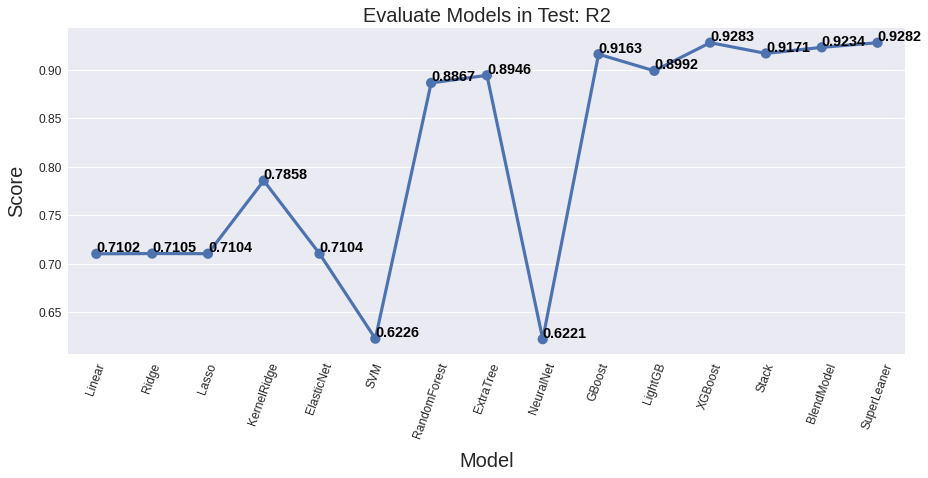

```python
plot_model_score_regression(list(test_scores.keys()), [r2 for r2, mse, rmse in test_scores.values()], 'Evaluate Models in Test: R2')
```

## Feature Importance Go to TOC

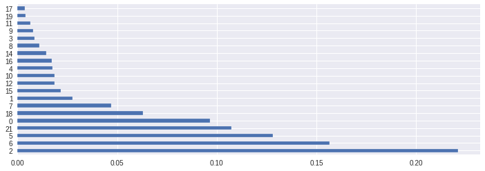

```python
# To one of best models: GBoost

plt.figure(figsize = (12,4))
feat_importances = pd.Series(regressor_models['XGBoost'].feature_importances_)#, index=X.columns)
feat_importances.nlargest(20).plot(kind='barh')
plt.show()
```

```
Time total to RFECV to Linear : took     2.305 s
```

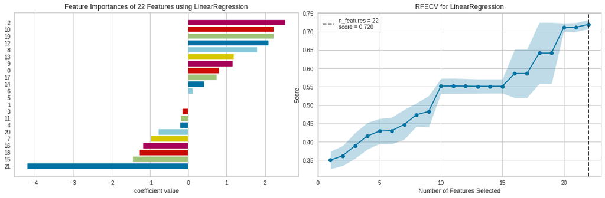

```python
from yellowbrick.model_selection import FeatureImportances, RFECV

# FeatureImportances and RFECV to a good model, if put GBoost(the best) take a long time

fig, (ax3,ax4) = plt.subplots(figsize = (15,5), ncols=2, sharex=False, sharey=False)

the_model = 'Linear'
t_start = time.time()

viz3 = FeatureImportances(regressor_models[the_model], ax=ax3, relative=False)
viz3.fit(x_train, y_train)
viz3.finalize()

viz4 = RFECV(regressor_models[the_model], ax=ax4)
viz4.fit(x_train, y_train)
viz4.finalize()

print('Time total to RFECV to {} : took {:9,.3f} s'.format(the_model, time.time() - t_start))

plt.show()
```

## Evaluate Best Model Go to TOC

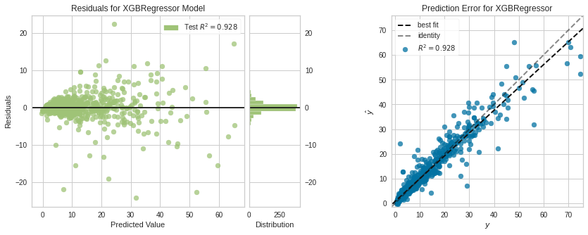

```python
from yellowbrick.regressor import ResidualsPlot, PredictionError
from yellowbrick.model_selection import FeatureImportances, RFECV

# Can't use 'SuperLeaner' than, use the second place: GBoost

fig, (ax1, ax2) = plt.subplots(figsize = (15,5), ncols=2)

viz1 = ResidualsPlot(regressor_models['XGBoost'], ax=ax1)
viz1.score(x_test, y_test)
viz1.finalize()

viz2 = PredictionError(regressor_models['XGBoost'], ax=ax2)
viz2.score(x_test, y_test)
viz2.finalize()

plt.show()
```

## Conclusion Go to TOC

```python
from sklearn.metrics import mean_absolute_error, mean_squared_log_error

y_pred = regressor_models['XGBoost'].predict(x_test)
print('The best Regressor Model to Test DataSet:')
print('MAE : {:14,.3f}'.format(mean_absolute_error(y_pred, y_test)))
print('MSE : {:14,.3f}'.format(mean_squared_error(y_pred, y_test)))
print('RMSE: {:14,.3f}'.format(np.sqrt(mean_squared_error(y_pred, y_test))))
print('R2  : {:14,.3f}'.format(r2_score(y_pred, y_test)))
```

```
The best Regressor Model to Test DataSet:
MAE :          1.302
MSE :          7.238
RMSE:          2.690
R2  :          0.922
```

This Kernel is still under development. I would highly appreciate your feedback for improvement and, of course, if you like it, please upvote it!

Please Upvote (It motivates me)